# 24133064_NguyenThiKieuTrang_EXERCISES_MODEL

# 9. Trực quan hóa model

## Decision Tree

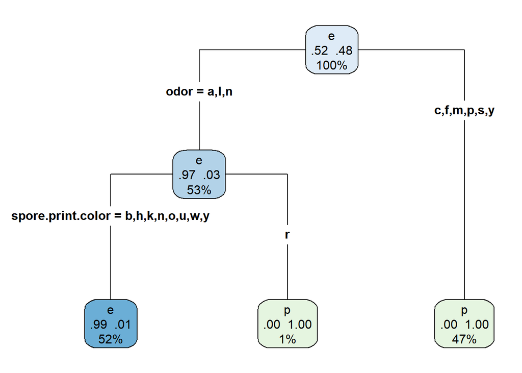

```r
rpart.plot(
  model_tree,
  type = 4,
  extra = 104,
  fallen.leaves = TRUE
)
```

- Từ cây quyết định có thể thấy thuộc tính odor (mùi nấm) là thuộc tính quan trọng nhất trong việc phân loại nấm. Mô hình chọn odor làm nút phân chia đầu tiên vì thuộc tính này giúp tách hai nhóm nấm ăn được và nấm độc hiệu quả nhất.
- Với nhánh có odor = a,l,n (almond, anise, none), mô hình dự đoán phần lớn là nấm ăn được (e) với độ chính xác khoảng 97%. Trong nhóm này, thuộc tính tiếp theo được sử dụng là spore.print.color để phân loại chính xác hơn. Với các giá trị mùi như c,f,m,p,s,y (creosote, foul, musty, pungent, spicy, fishy), mô hình dự đoán nấm độc (p) với độ chính xác gần 100%.
- Điều này cho thấy odor là một đặc trưng rất có giá trị trong việc nhận biết nấm độc, giúp Decision Tree đưa ra quyết định nhanh và dễ giải thích.

## Logistic Regression

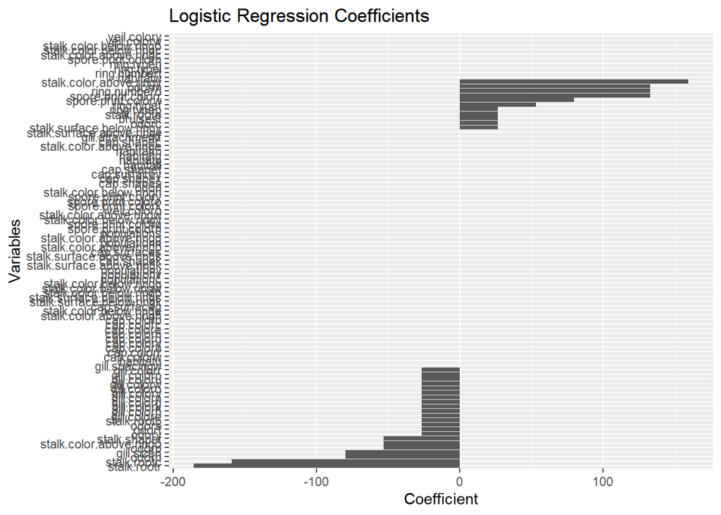

```r
coef_df <- data.frame(
  Variable = names(coef(model_logit)),
  Coefficient = coef(model_logit)
)
coef_df <- coef_df[-1, ]
ggplot(coef_df,
       aes(x = reorder(Variable, Coefficient),
           y = Coefficient)) +
  geom_bar(stat = "identity") +
  coord_flip() +
  labs(
    title = "Logistic Regression Coefficients",
    x = "Variables",
    y = "Coefficient"
  )
```

- Biểu đồ hệ số của Logistic Regression cho thấy mô hình đã xác định mức độ ảnh hưởng của từng thuộc tính đến kết quả phân loại nấm.
- Các biến có hệ số dương lớn làm tăng khả năng dự đoán mẫu nấm là nấm độc (p), trong khi các biến có hệ số âm lớn làm tăng khả năng dự đoán mẫu là nấm ăn được (e).
- Một số thuộc tính có ảnh hưởng đáng kể đến quá trình dự đoán như odor, stalk-color, spore-print-color và các đặc trưng liên quan đến gill.
- Tuy nhiên, do bộ dữ liệu Mushroom chứa nhiều thuộc tính dạng phân loại nên Logistic Regression cần chuyển đổi thành nhiều biến giả (dummy variables), làm số lượng hệ số tăng lên nhiều và khiến biểu đồ khó quan sát hơn. Điều này cho thấy Logistic Regression vẫn có khả năng phân loại tốt nhưng khả năng giải thích trực quan không bằng Decision Tree.